# Praca domowa 3

# Jak to naprawić?

Przede wszystkim, zamiast wykresu kołowego, zastosujemy wykres słupkowy. Przyjmiemy założenie, że pełna kwota to faktycznie 500 mln, a dane z pola Norwegii potraktujemy jako zaokrąglone. Wtedy faktyczna kwota otrzymana przez Norwegię, Niemcy, Hiszpanię i Polskę to:

```r
500 * 0.175 # Norwegia
```

```
## [1] 87.5
```

```r
500 * 0.242 # Niemcy
```

```
## [1] 121
```

```r
500 * 0.048 # Hiszpania
```

```
## [1] 24
```

```r
500 * 0.004 # Polska
```

```
## [1] 2
```

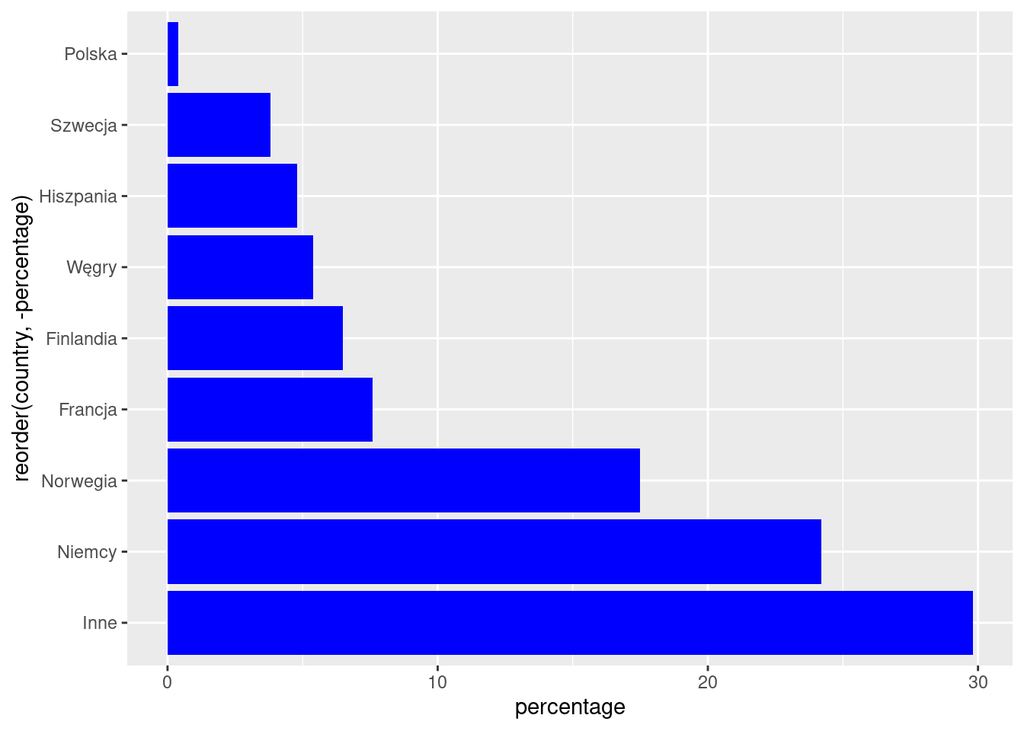

```r
data = data.frame(country = c("Niemcy", "Norwegia", "Polska", "Węgry", "Finlandia",
                              "Francja", "Hiszpania", "Szwecja", "Inne"),
                  value = c(121, 87.5, 2, 27, 32.5, 38, 24, 19, 149)) %>%
  mutate(percentage = value/5)
plot = data %>%
  ggplot(aes(x = reorder(country, -percentage),
             y = percentage)) +
  geom_col(fill = "blue")+
  coord_flip()

plot
```

Jak widać kilka linijek kodu potrafi wygenerować znacznie lepszy wykres. Poprawimy jeszcze trochę estetykę:

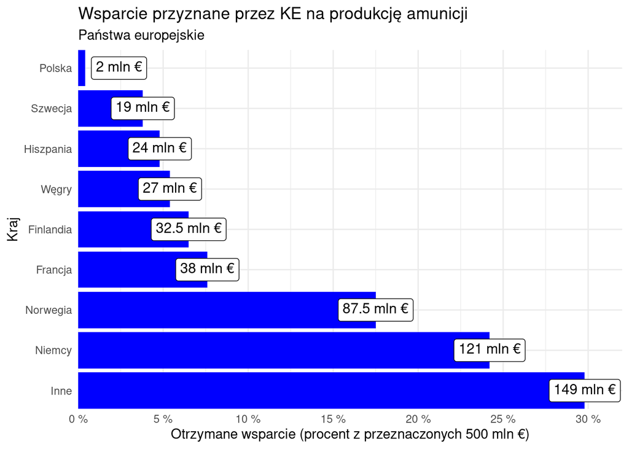

```r
plot +
  labs(x = "Kraj",
      y = "Otrzymane wsparcie (procent z przeznaczonych 500 mln €)",
      title = "Wsparcie przyznane przez KE na produkcję amunicji",
      subtitle = "Państwa europejskie")+
  scale_x_discrete(expand = c(0,0))+
  scale_y_continuous(limits = c(0, 32),
                     breaks = seq(0, 35, 5),
                     label = paste(seq(0, 35, 5), "%"),
                     expand = c(0,0))+
  theme_minimal()+
  geom_richtext(
    data = subset(data, value >=15),
    aes(label = paste(value, "mln €")),
    position = position_stack(),
    size = 4)+
  geom_richtext(
    data = subset(data, value <15),
    aes(label = paste(value, "mln €")),
    position = position_stack(vjust = 6),
    size = 4)
```

Tym razem pracy było ciut więcej, ale otrzymany wykres znacznie lepiej prezentuje dane. Najlepiej widać to na przykładzie poprzednio nierozróżnialnych danych na temat Węgier i Finlandii. Na wykresie kołowym trudno dostrzec różnicę i gdyby nie podpisy, można by sądzić, że wartości są podobne. Słupki są dodatkowo podpisane, więc żadna informacja z wyjściowego wykresu nie została utracona, a wręcz przeciwnie - nareszcie wiemy, ile pieniędzy otrzymali Niemcy i Hiszpanie. Dodatkowo, dane są ustawione rosnąco, co ułatwia ustalenie które państwo dostało największą dotację.